# Social Forecasting Tutorial 1

Martyn Egan

16/03/2023

# Time Series in R and Visualisation

## The `ts` object

R has a built-in data format for time series data, the `ts` object. We create `ts` objects using the `ts()` function, which has arguments `x` (a vector, matrix or data frame to be coerced), `start` (the time of the first observation, either a single number or a vector of two numbers, the second of which is an integer corresponding to the time unit), `end` (the time of the last observation, possibly optional), and `frequency` (the number of observations per unit of time, i.e. 12 for months, 4 for quarters).

```r
amtrak <- read.csv("data/Amtrak.csv")

amtrak.ts <- ts(amtrak$Ridership, start = c(1991, 1), end = c(2004, 3), frequency = 12)
```

## Indexing and subsetting a `ts` object

There are several ways to subset and index a time series object. A useful function is `window()`, which takes the arguments `x`, a time-series object, `start` and `end` (which behave the same as in the `ts()` function). We can also use square bracket indexing with the `cycle()` function to, for example, sub-set certain units (months, quarters, etc.)

The `forecast` package contains a method for the `subset()` function which extends it to the `ts` class, allowing subsetting on, for example `month` or `quarter`.

```r
window(amtrak.ts, start = 1995, end = c(2000, 5)) #subset from 1995 to May 2000 inclusive
```

```
##           Jan      Feb      Mar      Apr      May      Jun      Jul      Aug
## 1995 1548.415 1496.925 1798.316 1732.895 1772.345 1761.207 1791.655 1874.820
## 1996 1381.758 1360.852 1558.575 1608.420 1696.696 1693.183 1835.516 1942.573
## 1997 1396.588 1371.690 1707.522 1654.604 1762.903 1775.800 1934.219 2008.055
## 1998 1570.330 1412.691 1754.641 1824.932 1843.289 1825.964 1968.172 1921.645
## 1999 1599.427 1548.804 1832.333 1839.720 1846.498 1864.852 1965.743 1949.002
## 2000 1541.660 1616.928 1919.538 1971.493 1992.301
##           Sep      Oct      Nov      Dec
## 1995 1571.309 1646.948 1672.631 1656.845
## 1996 1551.401 1686.508 1576.204 1700.433
## 1997 1615.924 1773.910 1732.368 1796.626
## 1998 1669.597 1791.474 1816.714 1846.754
## 1999 1607.373 1803.664 1850.309 1836.435
## 2000
```

```r
amtrak.ts[cycle(amtrak.ts) == 1] #subset all data from January
```

```
##  [1] 1708.917 1614.827 1705.259 1563.365 1548.415 1381.758 1396.588 1570.330
##  [9] 1599.427 1541.660 1683.148 1759.629 1778.033 1831.508
```

```r
subset(amtrak.ts, month = "Jan") #subset all data from January
```

```
## Time Series:
## Start = 1991
## End = 2004
## Frequency = 1
##  [1] 1708.917 1614.827 1705.259 1563.365 1548.415 1381.758 1396.588 1570.330
##  [9] 1599.427 1541.660 1683.148 1759.629 1778.033 1831.508
```

## Plotting a `ts` object

`R`’s base plotting function contains a method for `ts` objects. The `forecast` package contains an extension to `ggplot2`’s `autoplot()` function, which extends it to `ts` objects.

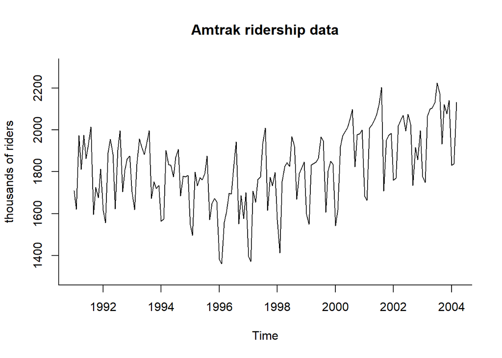

```r
plot(amtrak.ts, xlab = "Time",
     ylab = "thousands of riders",
     main = "Amtrak ridership data",
     ylim = c(1300, 2300), bty = "l")
```

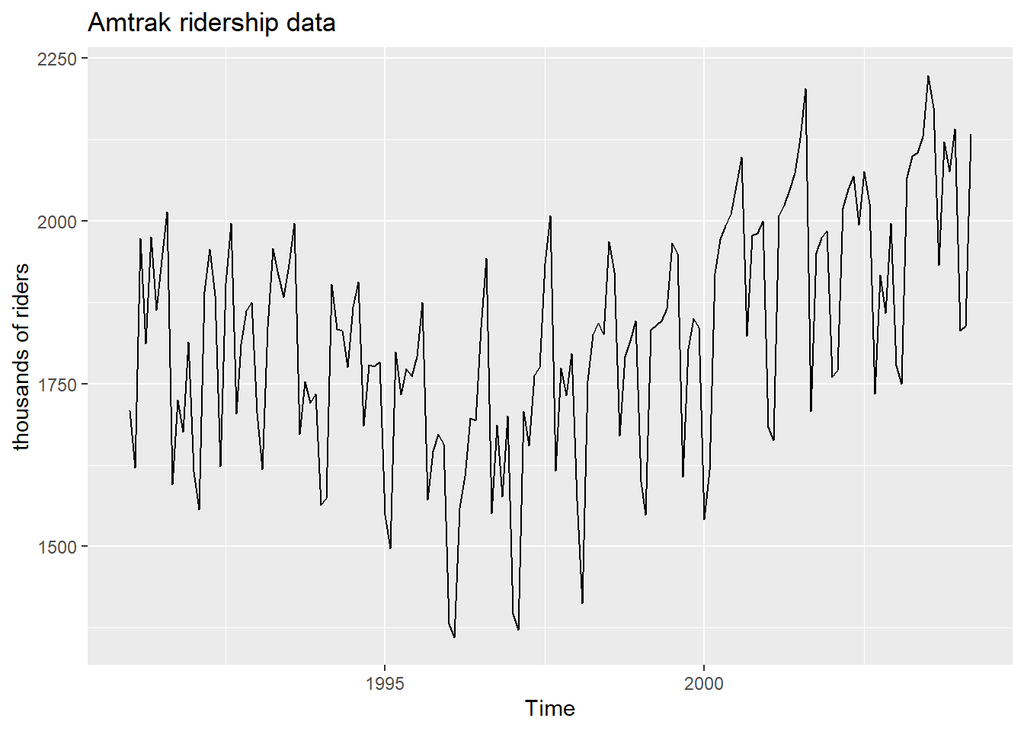

```r
autoplot(amtrak.ts) +
  labs(title = "Amtrak ridership data") +
  ylab("thousands of riders")
```

## Time series components

Visualising time series data enables us to discern the main components of the series. These are **level**, the average value of the series; **trend**, any long-term increase or decrease in the data; **seasonality**, which are regular patterns corresponding to the calendar (a related component is **cyclic** behaviour, which are rises and falls not of a fixed calendar period); and **noise**, which is the random variation in our data.

The Amtrak data we plotted above has a level of around 1.8m passengers per month. There is a slight U-shaped trend, and also annual seasonality, with peak travel in the summer months of July and August.

## More advanced plotting

The `forecast` package extends a number of `ggplot2`’s capabilities to create more advanced time series visualisations. Among these are the `ggseasonplot()` and `ggsubseriesplot()` functions.

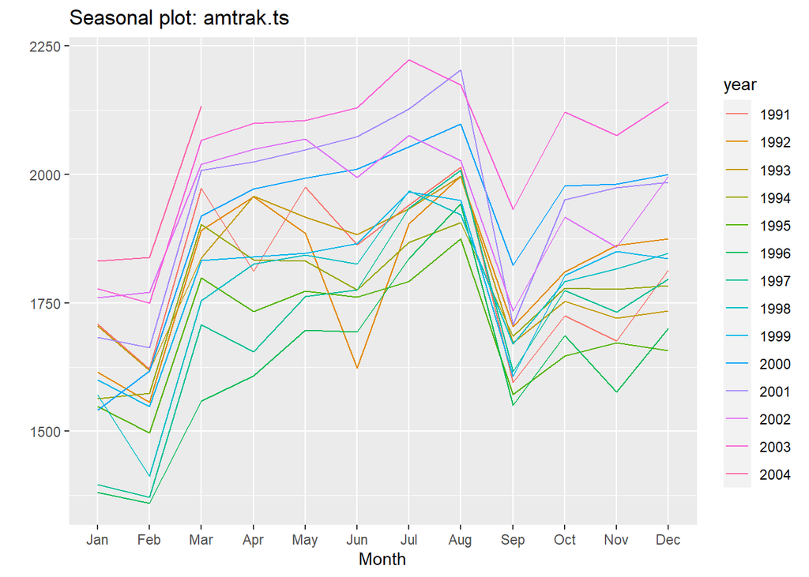

```r
ggseasonplot(amtrak.ts) #showing us seasonal trends
```

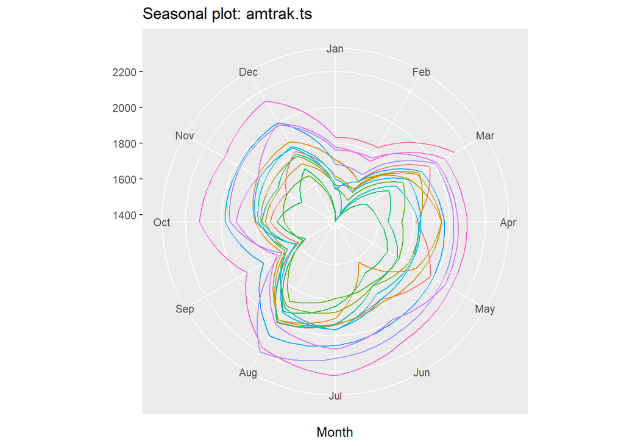

```r
ggseasonplot(amtrak.ts, polar = TRUE) + #a polar representation
  theme(legend.position="none") #suppress the legend
```

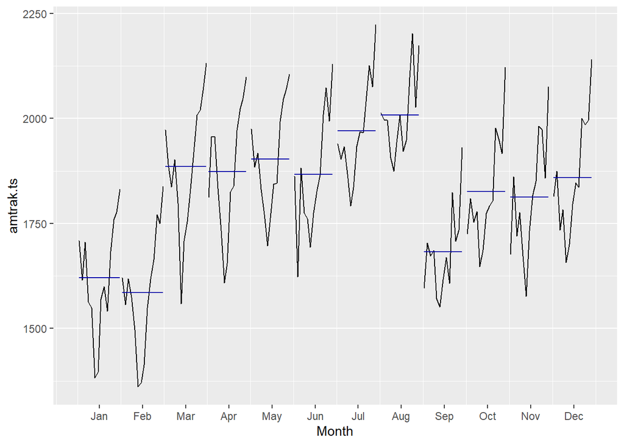

```r
ggsubseriesplot(amtrak.ts) #showing us the trend in each month across the whole series
```

### Task

Using the ApplianceShipments.csv file (a series of quarterly shipments (in millions of USD) of US household appliances between 1985-1989):

- Inspect the dataset and convert it to an appropriately formatted `ts` object.
- Create a well-formatted time plot of the data.
- Which of the four components (level, trend, seasonality, noise) seem to be present in this series?

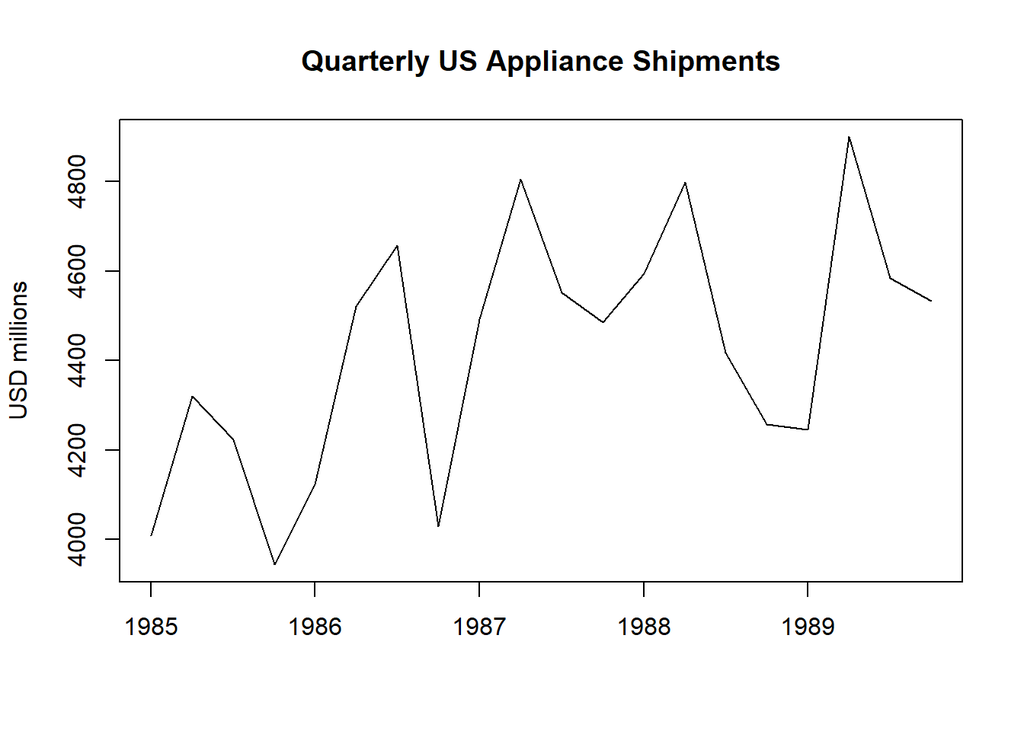

```r
aps <- read.csv("data/ApplianceShipments.csv") #read in the csv

aps.ts <- ts(aps[,-c(1, 3, 4)], start = c(1985, 1), frequency = 4) #convert to ts

plot(aps.ts, xlab = "", ylab = "USD millions", main = "Quarterly US Appliance Shipments")
```

Level, seasonality and noise are present, and possibly a slight upward trend.

## Trends

An additional visual aid can be the addition of a trend line to the time series. We will look more closely at smoothing techniques in the coming weeks. For now though, we will use the `tslm()` function in the `forecast` package to add a simple quadratic trend line to our Amtrak data (to attempt to model the U-shaped curve).

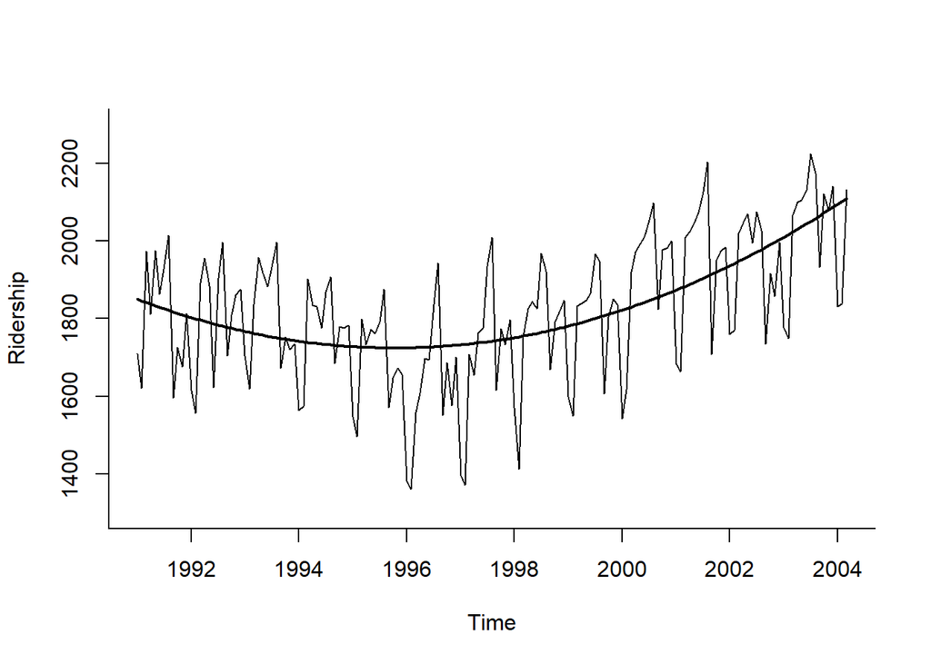

```r
amtrak.lm <- tslm(amtrak.ts ~ trend + I(trend^2))

plot(amtrak.ts, xlab = "Time", ylab = "Ridership", ylim = c(1300, 2300), bty = "l")
lines(amtrak.lm$fitted, lwd = 2)
```

### Task

The `Sept11Travel.csv` dataset analyses monthly passenger movement data between January 1990 and April 2004, in terms of 1) airline revenue passenger miles (Air), 2) rail passenger miles (Rail), and 3) vehicle miles (Auto).

- Use the `window()` function to subset the data **before** September 2001.
- Plot one of the time series (Air, Rail or Auto)
- What trend appears? Try changing the scale of the series, adding trend lines and suppressing seasonality to better visualise the trend pattern.

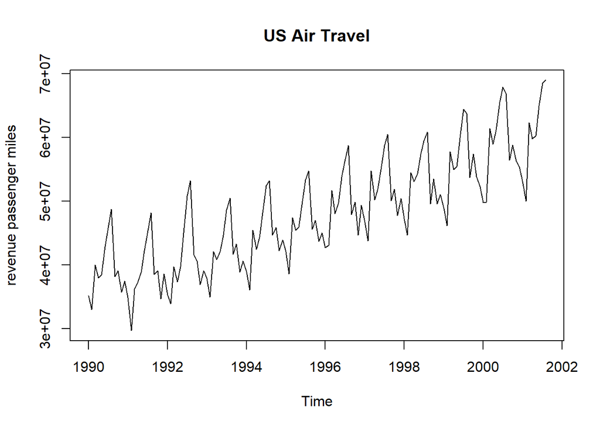

```r
sept11 <- read.csv("data/Sept11Travel.csv")
sept11.ts <- ts(sept11[,-1], start = c(1990, 1), end = c(2004, 4), frequency = 12)
pre.ts <- window(sept11.ts, end = c(2001, 8))

plot(pre.ts[,1], ylab = "revenue passenger miles", main = "US Air Travel")
```

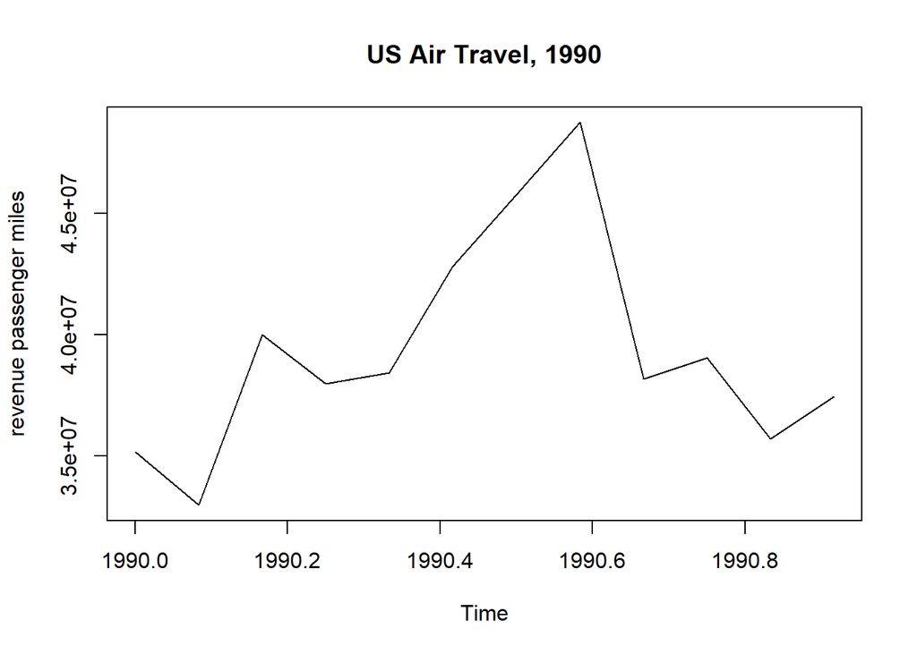

```r
plot(window(pre.ts[,1], start = c(1990,1), end = c(1990,12)),
     ylab = "revenue passenger miles", main = "US Air Travel, 1990")
```

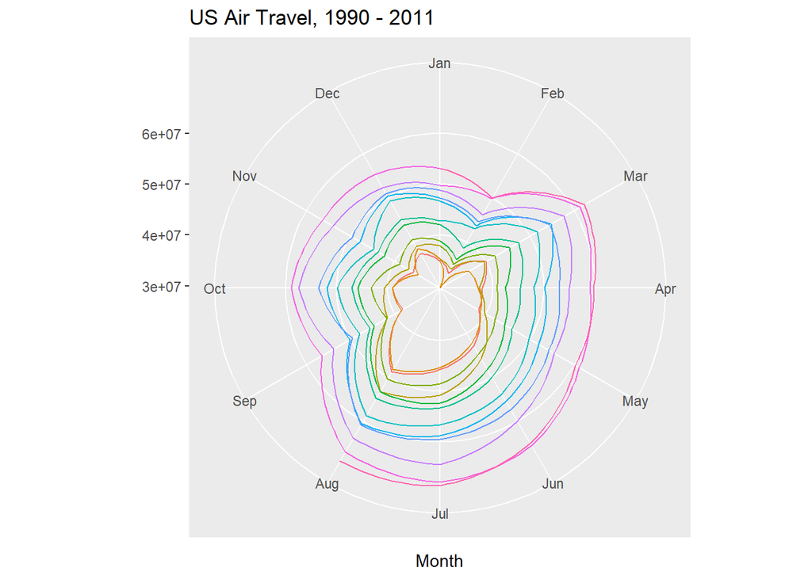

```r
ggseasonplot(pre.ts[,1], polar = TRUE) +
  ggtitle("US Air Travel, 1990 - 2011") +
  theme(legend.position="none")
```

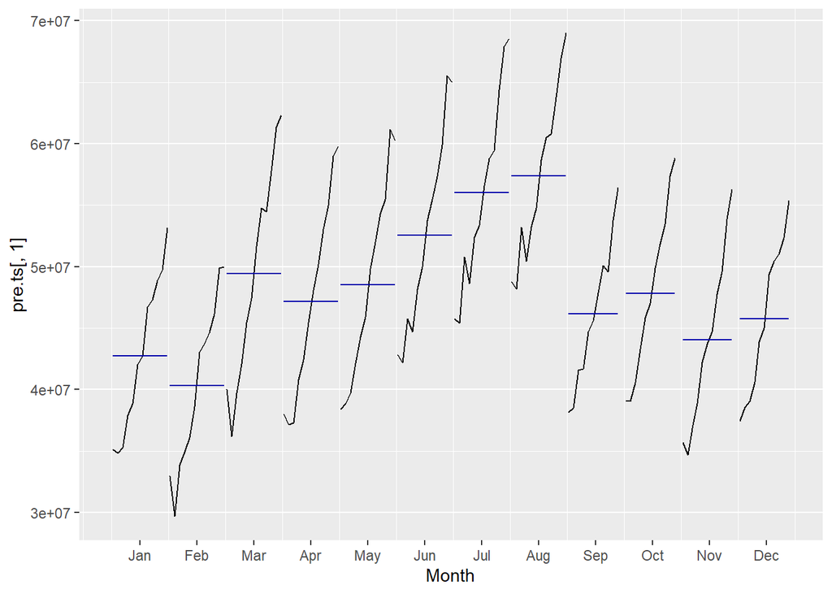

```r
ggsubseriesplot(pre.ts[,1])
```

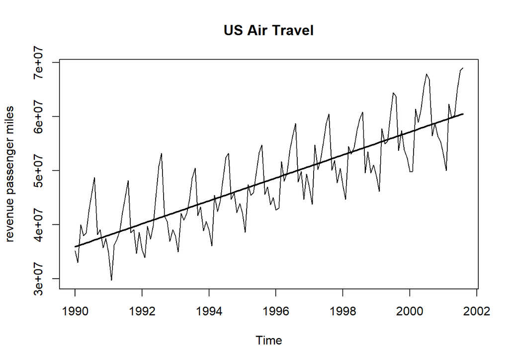

```r
air.lm <- tslm(pre.ts[,1] ~ trend)
plot(pre.ts[,1], ylab = "revenue passenger miles", main = "US Air Travel")
lines(air.lm$fitted, lwd = 2)
```